# Digital Capacities Index - Quantitative Findings

### Social Connectedness

Our survey asked participants to respond to questions about social connectedness and the role technology plays in their interactions with other people.

- Frequency of online activity to maintain connections
- Importance of online life to maintaining relationships
- Level of agreement with statements about broader issues concerning technology

##### Maintaining connections

This question measures frequency of 8 different online activities whose main purpose, or direct consequence, is to interact with others and/or to maintain connections.

The graph below shows the relative frequencies of each activity. Reading updates from friends or family via email or social media is the most frequent and most commonly reported activity, followed by making comments on those updates. Making new friends, meeting people or looking at websites that help meet new people are less common. This suggests that online activity is primarily used to strengthen connection with offline networks rather than as a distinct circle of connections.

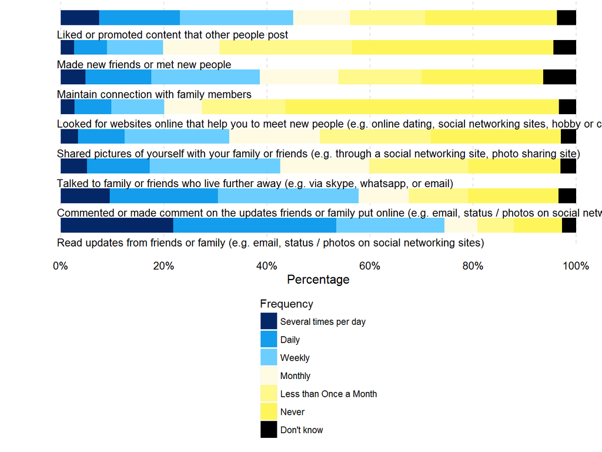

##### Importance of online life in maintaining relationships

When asked how important online life is in maintaining relationships with various groups within a broader social network, friends and family were the two groups with the highest level of importance. Online is also considered important in maintaining relationships with other networks of interest and work or school peers, but comparatively not as important to maintain relationships with neighbours.

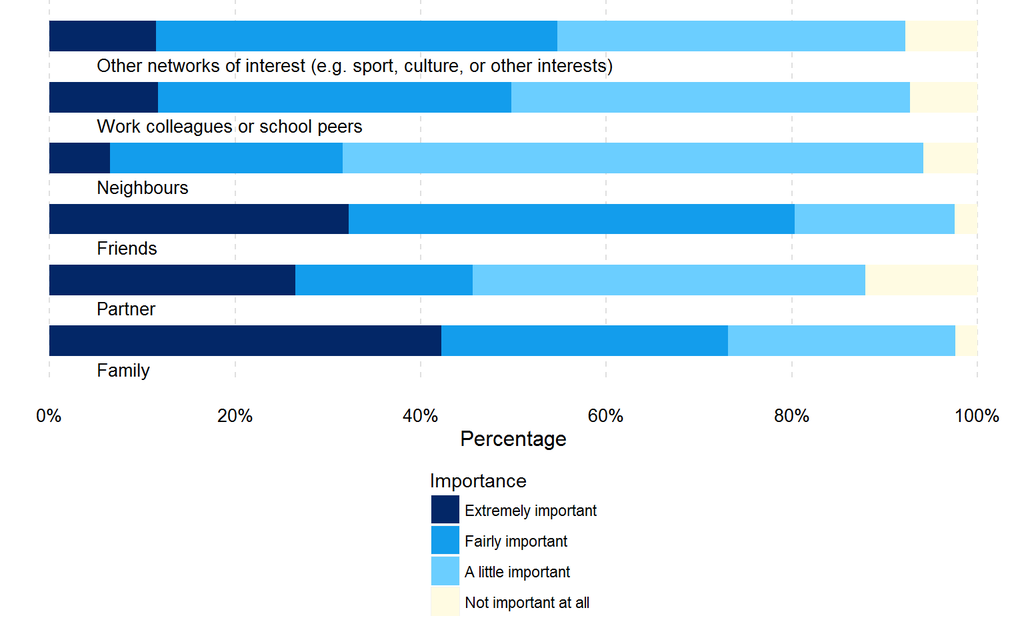

##### Attitudes towards Technology

The survey asked respondents to what extent they agree or disagree with a number of statements with regards to attitudes towards broader issues concerning technology.

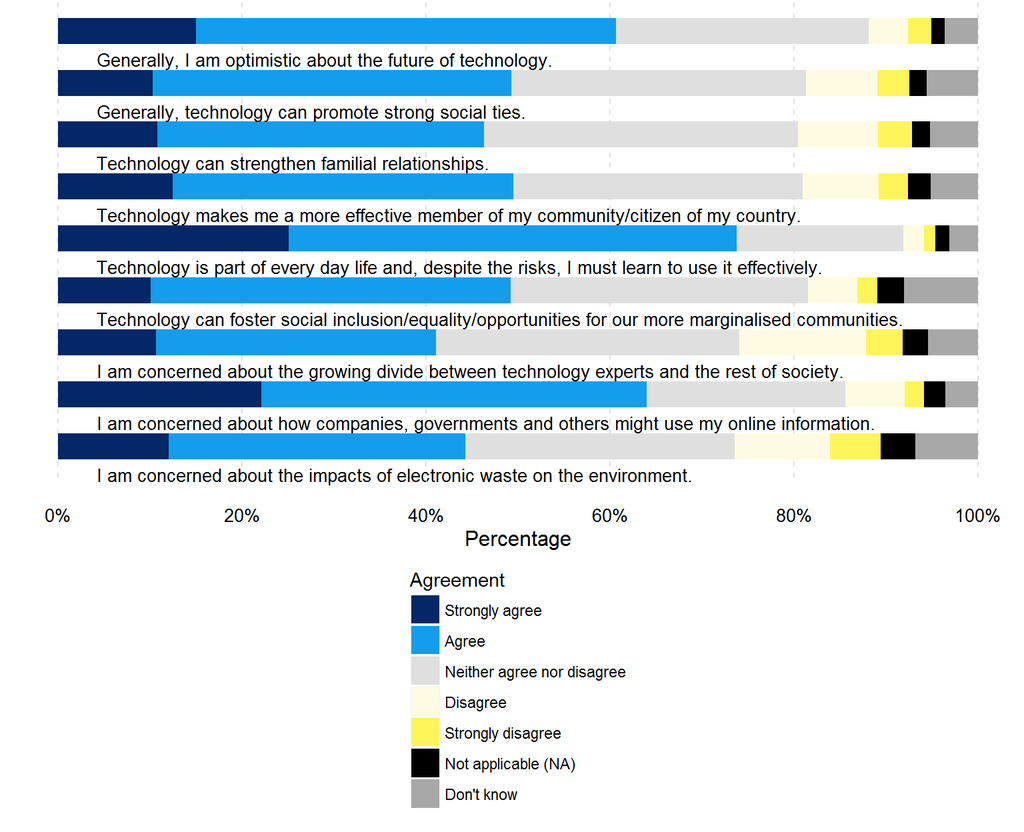

#### Results by Age

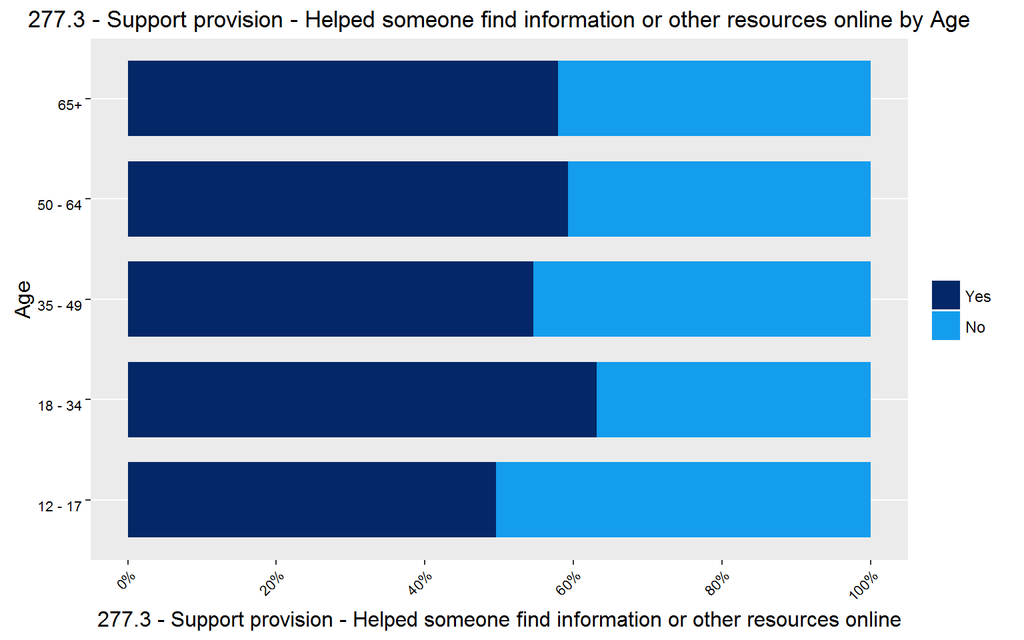

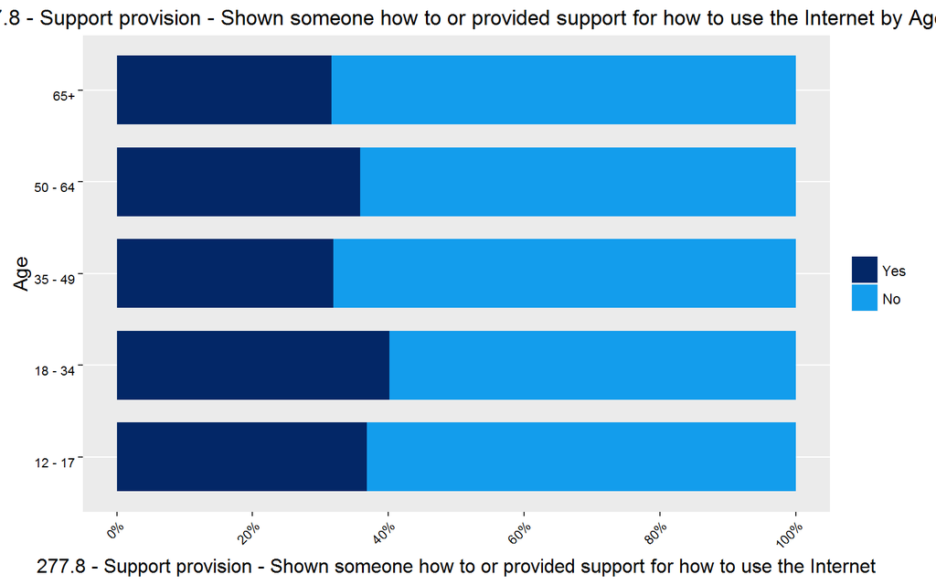

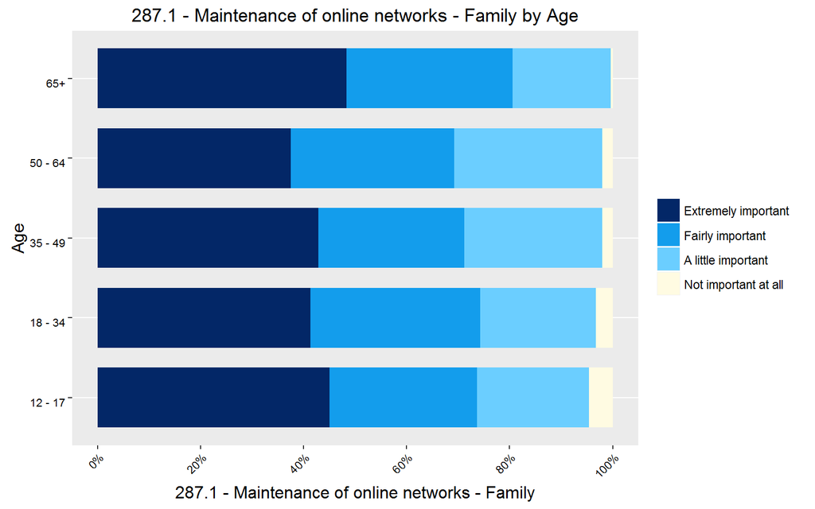

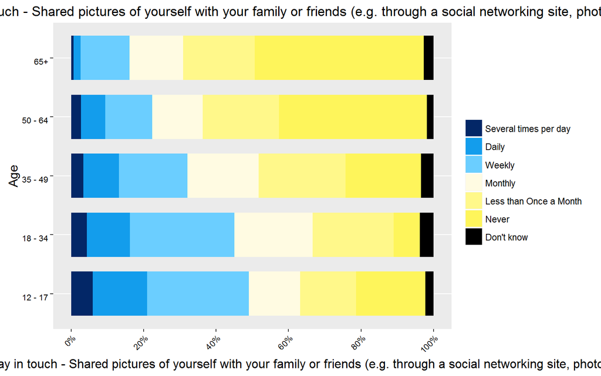

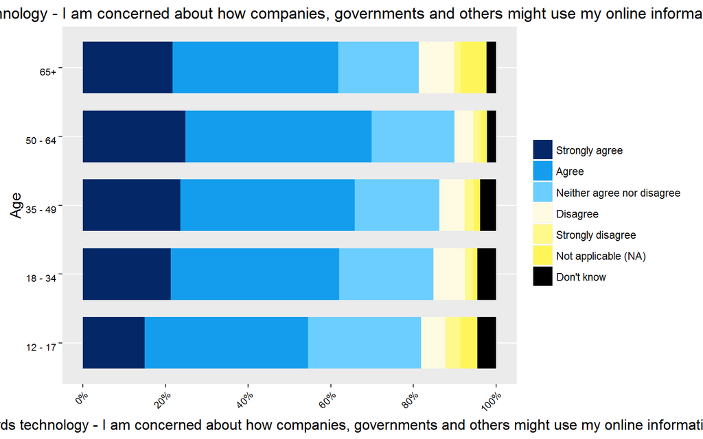

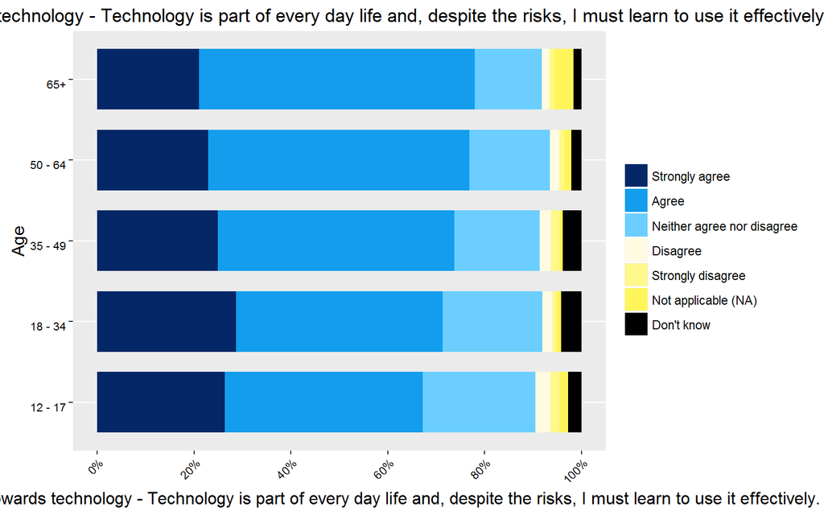

## Overall results

### Aggregates by Critical Issue

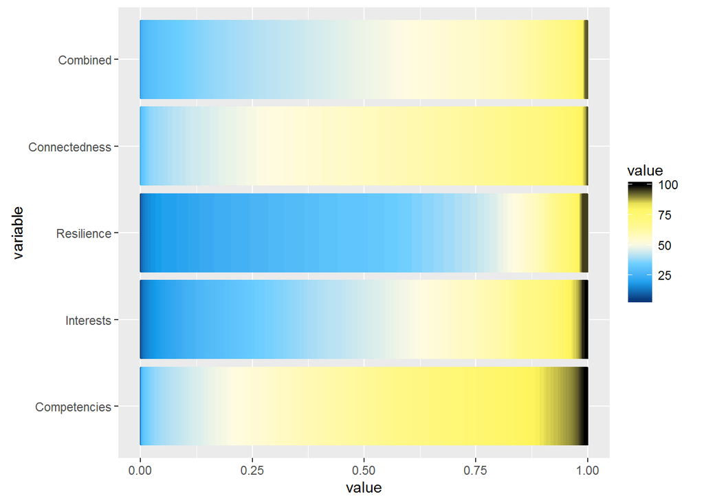

## References

Helsper, Ellen. 2012. “A Corresponding Fields Model for the Links Between Social and Digital Exclusion.” *Communication Theory* 22 (4). Wiley Online Library: 403–26.

Humphry, Justine. 2014. “The Importance of Circumstance: Digital Access and Affordability for People Experiencing Homelessness.” *Australian Journal of Telecommunications and the Digital Economy* 2 (3). Telecommunications Association: 55.

James, Paul. 2014. *Urban Sustainability in Theory and Practice: Circles of Sustainability*. Routledge.

Livingstone, Sonia, Leslie Haddon, Anke Görzig, and Kjartan Ólafsson. 2010. “Risks and Safety on the Internet: The Perspective of European Children: Key Findings from the EU Kids Online Survey of 9-16 Year Olds and Their Parents in 25 Countries.” EU Kids Online.